# FigureYa160scGSVA

小丫画图出品

2020-2-16

欢迎关注“小丫画图”公众号，回复“小白”，看小视频，实现点鼠标跑代码。

小丫微信: epigenomics E-mail: figureya@126.com

作者：Jinen

小丫编辑校验

# 需求描述

对单细胞亚群进行功能注释后，如何求每群细胞某条pathway的gene set score

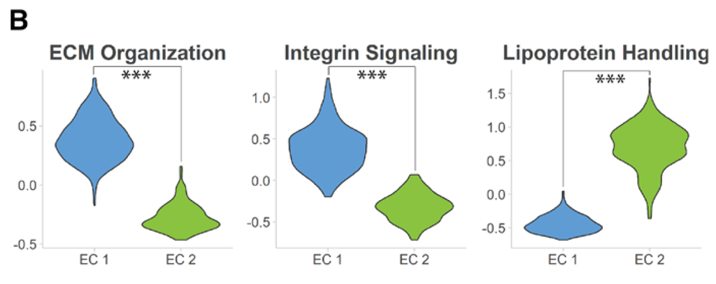

出自https://www.ahajournals.org/doi/10.1161/CIRCULATIONAHA.118.038362

Figure 5. Pathway analysis of endothelial cell (EC) subpopulations. B, Functional gene sets identified from Reactome pathway enrichment and subpopulation markers differentiate the 2 major EC populations EC 1 and EC 2.

# 应用场景

单细胞数据，从matrix到分组，用GSVA计算pathway的表达量，然后比较pathway在组间的差异，画图。

# 环境设置

使用国内镜像安装包

```r
options("repos"= c(CRAN="https://mirrors.tuna.tsinghua.edu.cn/CRAN/"))
options(BioC_mirror="http://mirrors.ustc.edu.cn/bioc/")
```

加载包

```r
library(dplyr)
```

```r
library(Seurat)
library(ComplexHeatmap)
library(GSVA)
library(GSEABase)
library(limma)
library(ggplot2)
Sys.setenv(LANGUAGE = "en") #显示英文报错信息
options(stringsAsFactors = FALSE) #禁止chr转成factor
```

加载自定义函数

做单细胞分析时，代码会非常多而且繁杂，为了脚本的整洁简短，我们把这些函数单独放在一个文件里，使用时导入就可以了。

```r
source("seurat_pipeline.R")
```

# 输入文件

输入文件位于文件夹：pbmc3k_filtered_gene_bc_matrices/filtered_gene_bc_matrices/hg19/，包括raw gene expression matrix、barcode和gene annotation。

数据来源：https://s3-us-west-2.amazonaws.com/10x.files/samples/cell/pbmc3k/pbmc3k_filtered_gene_bc_matrices.tar.gz

```r
pbmc.data <- Read10X(data.dir = "pbmc3k_filtered_gene_bc_matrices/filtered_gene_bc_matrices/hg19/")
# Initialize the Seurat object with the raw (non-normalized data).
pbmc <- CreateSeuratObject(counts = pbmc.data, project = "pbmc3k", min.cells = 3, min.features = 200)
pbmc
```

```
## An object of class Seurat
## 13714 features across 2700 samples within 1 assay
## Active assay: RNA (13714 features)
```

主要步骤：

- STEP 1 : 对单细胞数据进行分组，获得分组信息
- STEP 2 : 进行GSVA分析、差异表达分析
- STEP 3 : 根据已经得到的分组信息，挑选感兴趣的通路，画图

# STEP 1: 对单细胞数据进行分组，获得分组信息

用于从raw gene expression matrix开始。

如果已经完成了聚类，请移动到STEP 2。

使用seurat分析单细胞数据需要注意的几个地方:

## 1. 数据过滤

1. 细胞内表达基因个数 <200 或 > 7500的过滤掉。这里过滤的上限和下限自己把控，没有固定值。过滤掉基因表达高的是为了减少多细胞比例
2. 在 <3 个细胞内有表达的基因，过滤掉。因为很多基因的表达值都是0，这种可以过滤掉很多表达全为0的基因
3. 线粒体基因比例，一定程度上代表这建库时细胞的完整性。如果线粒体基因比例太高，说明细胞非常有可能破损了，在油包水时就不完整了

MT genes% < 20% 左右，根据自己的数据把控。就算这里过滤的不严格，也没有关系，后面聚类时，这些高线粒体基因比例的细胞都会聚到一类。

后续分析时排除这些细胞就可以了。一般外周血数据中线粒体基因比例都很低。

## 2 聚类和降维可视化

这里有两个参数不好把控，一个是选择PCA结果中的PC个数，另一个就是resolution。

- PC个数选择，可以根据ElbowPlot(拐点图)，选择拐点出现位置附近的PC数即可。这个参数会影响聚类的结果已经后续降维图形的。
- resolution：这个参数相对的不那么重要，只是会影响分出的cluster的数目多少。当resolution选的比较大，cluster分的很多，后续分析也可以

根据marker genes等，对细胞类型进行定义，然后人为的把相同细胞类型的cluster合并。

一般细胞数目 5000 - 10000 左右时，选择 resolution = 1 都是可以的，细胞数量更多时可以选择2。自己根据分出的效果来调控，这个不影响大局。

## 用自定义函数`Seurat.pipeline`做预处理

整个过程中需要调整的就只有这几个参数了：

```r
Seurat.pipeline(RdsName = pbmc, outputname = "PBMC", MTfraction = 0.05, pc = 10, res = 0.6)
```

```
## Modularity Optimizer version 1.3.0 by Ludo Waltman and Nees Jan van Eck
##
## Number of nodes: 2700
## Number of edges: 100408
##
## Running Louvain algorithm...
## Maximum modularity in 10 random starts: 0.8429
## Number of communities: 9
## Elapsed time: 0 seconds
```

```r
# 这里需要运行几分钟
# 经过这一步的处理，现在在pbmc这个seurat object 的assays中存储了三种基因表达数据，保存在PBMC_pc10_res0.6.rds里
# (1) pbmc@assays$RNA@counts : raw count
# (2) pbmc@assays$RNA@data : Normalized data
# (3) pbmc@assays$RNA@scale.data: scaled之后的data
# 做GSVA分析时，使用normalized data就可以了.
```

提取出每个细胞的基因表达量和对应的分组信息。

> 查看生成的`PBMC_pc10_res0.6.pdf`文件，分成了9个cluster

如何鉴定每个cluster是什么细胞类型？经典的做法是找出每个cluster中的高表达的基因，然后根据经典的细胞marker来确定细胞类型，需要查找文献。方法见官网https://satijalab.org/seurat/v3.1/pbmc3k_tutorial.html

# STEP 2 : GSVA 分析和差异表达分析

选择感兴趣的两个细胞亚群（cluster），用GSVA算出pathway的表达量，然后对比，画出感兴趣的pathway的图。

```r
# 加载 STEP 1 获得的pbmc
pbmc <- readRDS("PBMC_pc10_res0.6.rds")

# 导入gmt文件，这里以MsigDB中的Hallmark为例
# MsigDB链接(https://www.gsea-msigdb.org/gsea/msigdb/)
# 下载文件时，注意选择对应的gene格式吗，一般10X的结果，都是gene symbol格式的。
genesets <- getGmt("h.all.v7.0.symbols.gmt")

### 1. 找到感兴趣的细胞组别，两者间进行比较
# 这里以cluster6和cluster8为例
subcluster = c(6, 8)
sub <- subset(pbmc, idents = subcluster)
df.data <- GetAssayData(object = sub, slot = "data")

# 将细胞所属的group信息保存起来
df.group <- data.frame(umi = names(Idents(sub)),
                       cluster = as.character(sub@meta.data$RNA_snn_res.0.6),
                       stringsAsFactors = F)
# 查看一下结果是什么样子的
head(df.group)
```

```
##              umi cluster
## 1 AAACCGTGTATGCG       6
## 2 AAATTCGATTCTCA       6
## 3 AACCTTACGCGAGA       6
## 4 AACGCCCTCGTACA       6
## 5 AACGTCGAGTATCG       6
## 6 AAGATTACCTCAAG       6
```

```r
### 2. 做gsva
# 因为是normalized后的数据，所以使用默认参数就可以了。根据自己的电脑cpu来调整parallel.sz
gsvascore <- gsva(data.matrix(df.data), genesets, parallel.sz = 2)
```

```
## Estimating GSVA scores for 50 gene sets.
## Computing observed enrichment scores
## Estimating ECDFs with Gaussian kernels
## Using parallel with 2 cores
##
```

```r
# 因为单细胞数据中有很多基因表达值为0，所以会出现红色的warning信息，没有关系。

# 查看一下结果
gsvascore[1:5, 1:5]
```

```
##                                     AAACCGTGTATGCG AAATTCGATTCTCA
## HALLMARK_TNFA_SIGNALING_VIA_NFKB       -0.08840689     0.11595306
## HALLMARK_HYPOXIA                       -0.25753819    -0.05625146
## HALLMARK_CHOLESTEROL_HOMEOSTASIS       -0.18223444    -0.07188328
## HALLMARK_MITOTIC_SPINDLE               -0.01228222    -0.10120971
## HALLMARK_WNT_BETA_CATENIN_SIGNALING     0.08150049     0.11211519
##                                     AACCTTACGCGAGA AACGCCCTCGTACA
## HALLMARK_TNFA_SIGNALING_VIA_NFKB      -0.046222829    -0.01910364
## HALLMARK_HYPOXIA                      -0.006029415    -0.16391786
## HALLMARK_CHOLESTEROL_HOMEOSTASIS      -0.025663407    -0.31059428
## HALLMARK_MITOTIC_SPINDLE              -0.038100486     0.01518001
## HALLMARK_WNT_BETA_CATENIN_SIGNALING   -0.033919189    -0.06979871
##                                     AACGTCGAGTATCG
## HALLMARK_TNFA_SIGNALING_VIA_NFKB        0.01502586
## HALLMARK_HYPOXIA                       -0.05703961
## HALLMARK_CHOLESTEROL_HOMEOSTASIS        0.05185326
## HALLMARK_MITOTIC_SPINDLE               -0.10561961
## HALLMARK_WNT_BETA_CATENIN_SIGNALING    -0.12714755
```

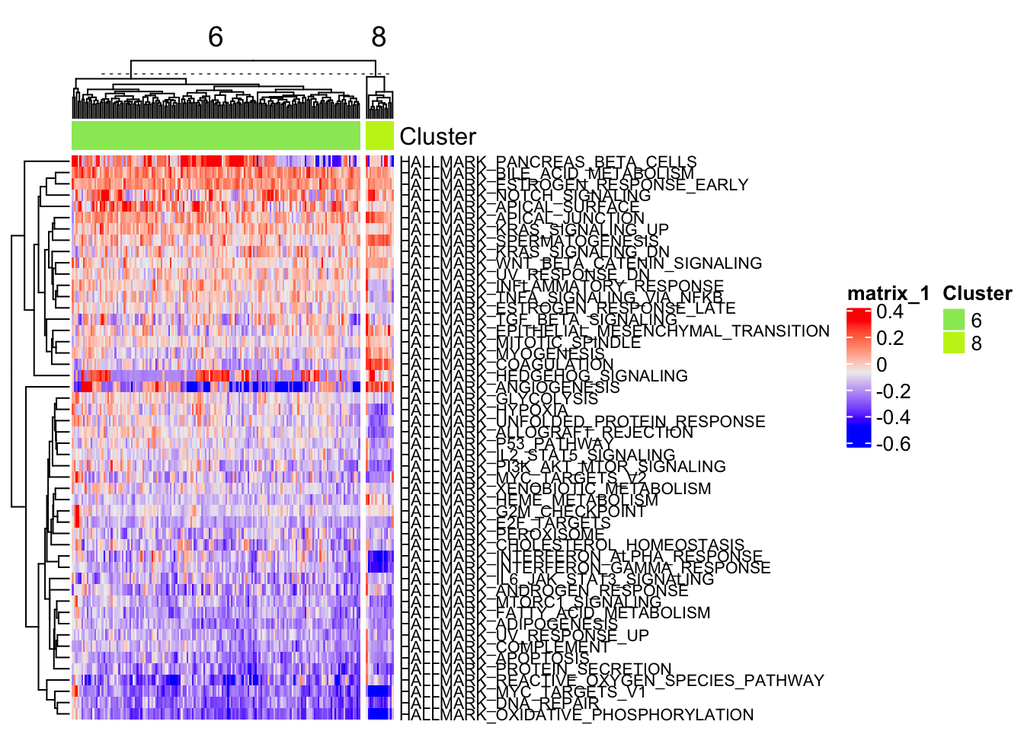

```r
# 先用热图展示一下hallmarker中全部的50个geneset得到的结果
ha.t <- HeatmapAnnotation(Cluster = df.group$cluster)
Heatmap(as.matrix(gsvascore),
        show_column_names = F,
        cluster_rows = T,
        cluster_columns = T,
        top_annotation = ha.t,
        column_split = df.group$cluster,
        row_names_gp = gpar(fontsize = 8),
        row_names_max_width = max_text_width(rownames(gsvascore),
                                             gp = gpar(fontsize = 8)))
```

```r
### 3. 挑选出要使用小提琴图展示的通路
# 使用limma包进行差异分析，然后根据差异分析结果，对通路进行选择。
cluster.group <- as.numeric(df.group$cluster)
# 确定分组信息
group2 <- 6
# 根据子集中细胞类型的名称来定
# 这里cluster6作为实验组（group2)，cluster8作为对照组（group1)
cluster.group[which(cluster.group != group2)] <- 0
cluster.group[which(cluster.group == group2)] <- 1
design <- cbind(sampleGroup1=1, sampleGroup2vs1=cluster.group)

# 利用limma包进行差异分析
fit <- lmFit(gsvascore, design)
fit <- eBayes(fit)
sigPathways <- topTable(fit, coef="sampleGroup2vs1",
                        number=Inf, p.value=0.05, adjust="BH")
# 添加一下分组信息，方便导出的数据区分实验组和对照组。
sigPathways$celltype <- rep(group2, length(nrow(sigPathways)))
# 保存到文件
write.csv(sigPathways, file = "PBMC_DE_genesets_hallmarker_cluster6_vs_8.csv")
```